# ggforce: Visual Guide

## Contextual zoom

Zooming in ggplot2 has always been done in one of two ways: By limiting the positional scale or by limiting the coordinate system. In the former actual data values are removed leading to a potential change in derived calculations ( e.g. a fitted line had different parameters) while the later behaves more as you would expect. ggforce provides a third option in the form of a new facetting function: `facet_zoom()`. Instead of describing it lets see how it works:

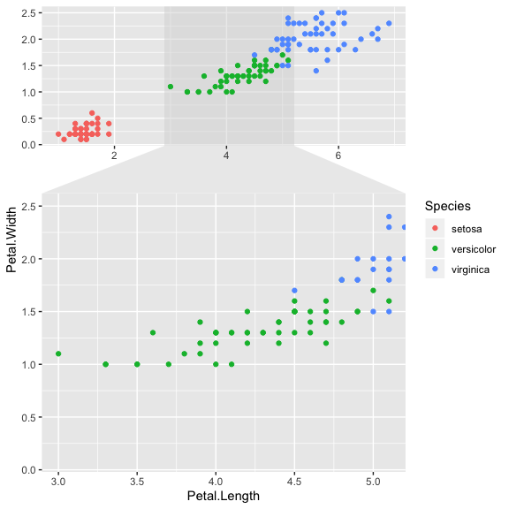

```r
ggplot(iris, aes(Petal.Length, Petal.Width, colour = Species)) +
    geom_point() +
    facet_zoom(x = Species == "versicolor")
```

As can be seen the main plot is now zoomed in on the data points that satisfies the condition given in the constructor, but an overview plot is retained along with an indication of the position of the zoomed in area. The example above is zooming in on the x-axis, but y-axis zoom is supported as well:

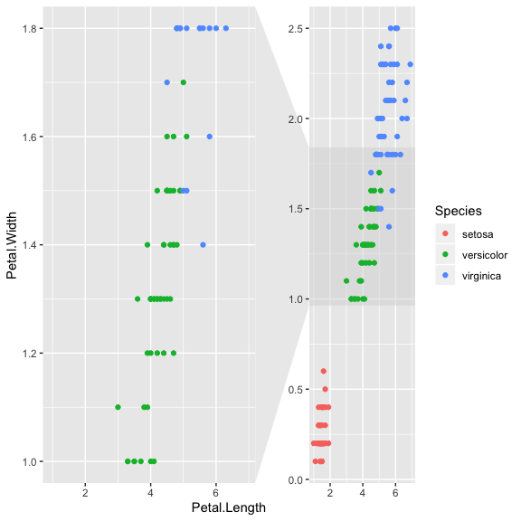

```r
ggplot(iris, aes(Petal.Length, Petal.Width, colour = Species)) +
    geom_point() +
    facet_zoom(y = Species == "versicolor")
```

Both axes can be zoomed in as well. If the same condition is used for both axes the `xy` shorthand can be used:

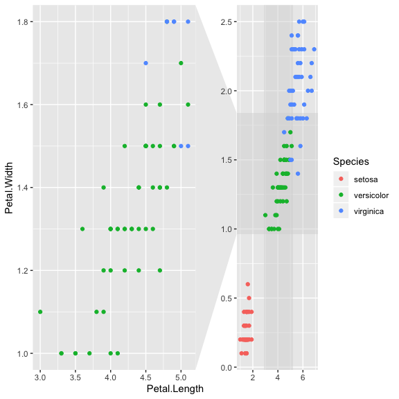

```r
# Zoom in on versicolor on both axes
ggplot(iris, aes(Petal.Length, Petal.Width, colour = Species)) +
    geom_point() +
    facet_zoom(xy = Species == "versicolor")
```

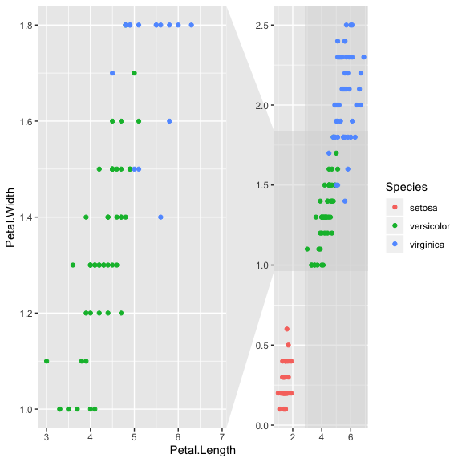

```r
# Use different zoom criteria on each axis
ggplot(iris, aes(Petal.Length, Petal.Width, colour = Species)) +
    geom_point() +
    facet_zoom(x = Species != 'setosa', y = Species == 'versicolor')
```

For a truly fanzy representation each axis zoom can be shown individually as well:

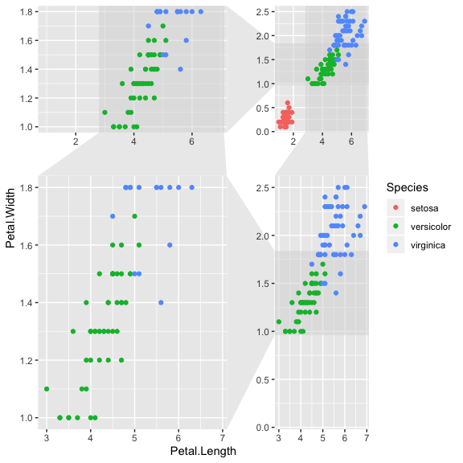

```r
ggplot(iris, aes(Petal.Length, Petal.Width, colour = Species)) +
    geom_point() +
    facet_zoom(x = Species != 'setosa', y = Species == 'versicolor',
               split = TRUE)
```

If you want to control the zoom area directly this can be done using the `xlim` and `ylim` arguments instead of `x` and/or `y`. This lets you set the range for the zoom panel. Furthermore it is possible to control which data gets plotted in the context and zoom panels selectively through the `zoom.data` argument that takes an expression to evaulate for each row in the data (as `x`, `y`, and `xy`) and assigns data to the zoom panel if it evaluates to `TRUE`, the context panel if it evaluates to `FALSE` and both if it evaulates to `NA` (the default). Combining all this into one plot we can get this:

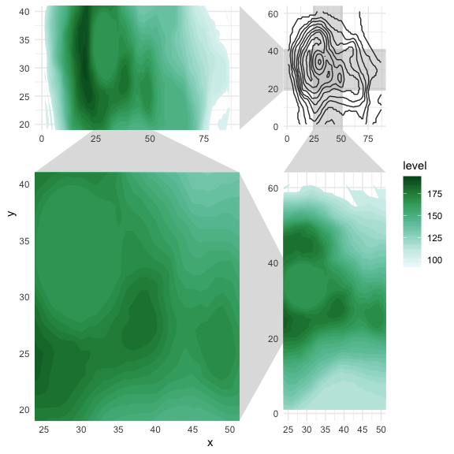

```r
volcano3d <- structure(reshape2::melt(volcano), names = c('x', 'y', 'z'))

ggplot() +
    stat_contour(aes(x, y, z = z), data = cbind(volcano3d, zoom = FALSE), geom = 'contour', colour = 'grey20') +
    stat_contour(aes(x, y, z = z, fill = ..level..), data = cbind(volcano3d, zoom = TRUE), geom = 'polygon', bins = 30) +
    facet_zoom(xlim = c(25, 50), ylim = c(20, 40), horizontal = FALSE, zoom.data = zoom, split = T) +
    scale_fill_distiller(direction = 1, palette = 2) +
    theme_minimal() +
    theme(zoom = element_rect(fill = 'grey75', colour = NA), validate = FALSE)
```

## Stereographic projection

One of the more “fun and useless” additions to ggforce is `facet_stereo` which allows the user to create a stereographic projection of the plot in order to make a faux 3D plot. `facet_stereo` shifts features sligtly to the left and right based on the provided `depth`-aesthetic to simulate how each eye will see a sligtly different picture when looking at a 3D scenery. In order to experience the 3D effect, either look at the plot with 3D hardware such as Google Cardboard or by using relaxed focusing where the eyes focus on the far distance while looking at the plot (the same technique used when looking at stereograms such as Magic Eye).

In order to use `facet_stereo` provide a depth aesthetic to the layers (will generate a warning) and modify the depth perception with `scale_depth`:

```
## Warning: Ignoring unknown aesthetics: depth
```

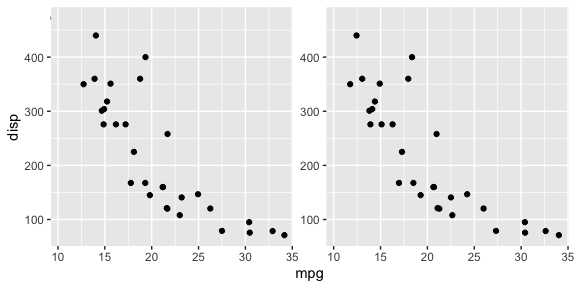

```r
ggplot(mtcars) +
    geom_point(aes(mpg, disp, depth = wt)) +
    scale_depth(range = c(0, 0.2)) +
    facet_stereo()
```

To improve the effect you can scale the size of the features as well as the colour to enhance the 3D feeling

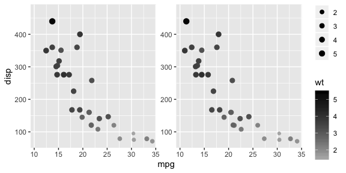

```r
ggplot(mtcars) +
    geom_point(aes(mpg, disp, depth = wt, colour = wt, size = wt)) +
    scale_size(range = c(1.5, 3)) +
    scale_color_gradient(low = 'grey70', high = 'black') +
    facet_stereo()
```

Note that due to the design of ggplot2 there are some limitations to this, most notably that layers will always be placed on top of each other no matter their depth values. This means that you can end up with features occluding other features in front of them. Also, even though grid lines are placed at `depth = 0` they will always be behind all features.

# Transformations

Transformations are not really a part of ggplot2, but rather the scales package. Nevertheless it is an integral part of working with ggplot2 through its use in manipulating scales. ggforce expands the use of transformations to also include coordinate transformations.

## Univariate transformations

This section describes the new transformations offered by ggforce for manipulating scales. In general the scales package has you well covered but there are some missing pieces:

### Power transformations

Suspicously missing from the scales package is a generalized power transformation that is, e.g. x<sup>2</sup>. This type of transformation is only represented by the square root transformation which equals x<sup>1/2</sup>. ggforce provides a constructor for power transformations that can be used on scales etc.

```r
p3 <- power_trans(3)
p3
```

```
## Transformer:  power of 3
```

```r
p3$transform(1:5)
```

```
## [1]   1   8  27  64 125
```

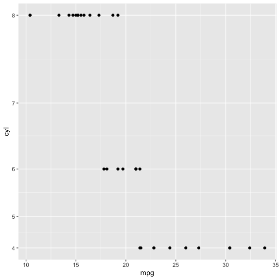

```r
ggplot(mtcars) + geom_point(aes(mpg, cyl)) + scale_y_continuous(trans = p3)
```

### Reversing transformations

Scales provide `reverse_trans()` to create a reverse linear transformation. Unfortunatly you’re out of luck if you want a reverse log transformation etc. ggforce provides a transformation modifier that can reverse any transformation object passed into it:

```r
p3r <- trans_reverser(p3)
p3r
```

```
## Transformer:  reverse-power of 3
```

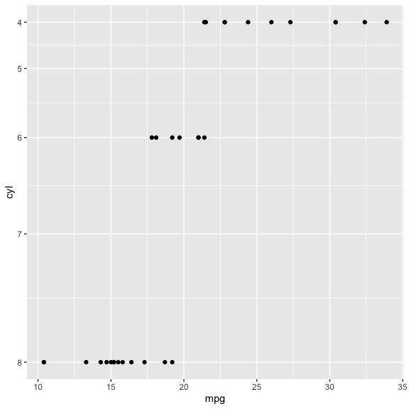

```r
ggplot(mtcars) + geom_point(aes(mpg, cyl)) + scale_y_continuous(trans = p3r)
```

## Coordinate transformations

Coordinate transformation takes coordinates and does something to them. It can be simple rotations, shearing and reflections as you know from different image processing applications, or translating between different ways of representing data, e.g. radial to cartesian transformations. These types of transformations are closely linked to applying different coordinate systems to your plot, e.g. using coord polar, but can be applied to your data upfront instead of on the whole plot.

### Radial transformations

`radial_trans()` converts radi and angle to x and y positions in a cartesian coordinate system. That means that if you have a point defined by its position on a circle you can easily get the x and y coordinates for it. The angle doesn’t need to be provided in radians or degrees as both the angular range and the radius range are defined when the transformation object is created. On top of that it can be defined where 0 starts (defaults to 12 o’clock) and which direction is used among others - see the documentation for radial_trans for a more in-depth description

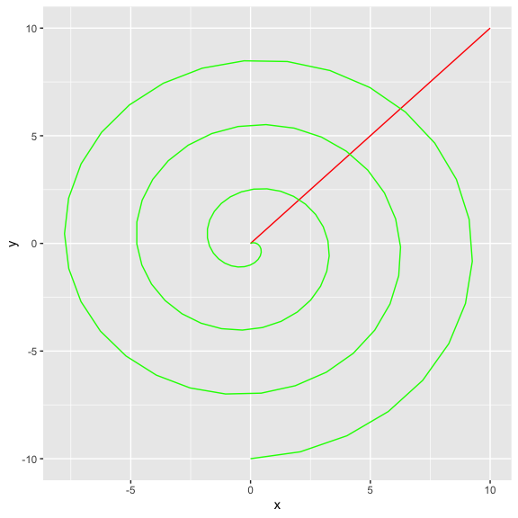

```r
line <- data.frame(
    x = seq(0, 10, length.out = 100),
    y = seq(0, 10, length.out = 100)
)
r_trans <- radial_trans(r.range = c(0, 1), a.range = c(0, 2))
spiral <- r_trans$transform(r = line$x, a = line$y)
ggplot() + geom_path(aes(x, y), data = line, colour = 'red') +
    geom_path(aes(x, y), data = spiral, colour = 'green')
```

### Linear transformation

The family of linear transformations cover scaling/stretching, rotation, shearing, reflection, and translation. All of these are implemented in the `linear_trans` constructor that lets you compose a sequence of transformation steps, either fixed or parameterized. To avoid dealing with transformation matrices and ease parameterisation each transformation is encapsulated into a function that creates a transformation matrix. All transformations are done relative to the origin so shapes needs to be translated into the origin if e.g. rotation around their own center (rather than [0, 0]) is required.

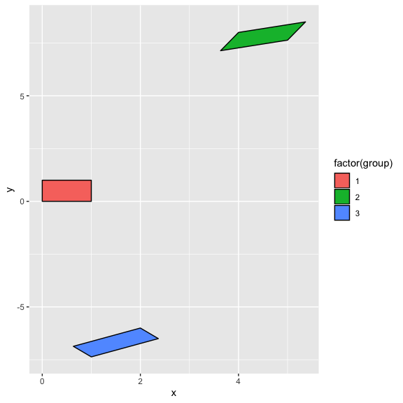

```r
# parameterized rotation and translation, fixed shearing
trans <- linear_trans(rotate(a), shear(1, 0), translate(x1, y1))
square <- data.frame(x = c(0, 0, 1, 1), y = c(0, 1, 1, 0))
square2 <- trans$transform(square$x, square$y, a = pi/3, x1 = 4, y1 = 8)
square3 <- trans$transform(square$x, square$y, a = pi/1.5, x1 = 2, y1 = -6)
square_all <- rbind(square, square2, square3)
square_all$group <- rep(1:3, each = 4)
ggplot(square_all, aes(x, y, group = group)) +
    geom_polygon(aes(fill = factor(group)), colour = 'black')
```

# Scales

Currently only a single new scale is added to ggplot2 with ggforce, but it is a rather nifty little fellow.

## Units

Often, when working with numeric data, there’s a unit attached to the values, but in R this unit is not attached to your data but rather lives in your head. The developers of the [units package](https://cran.r-project.org/package=units) has done something about this with the `units` class, which carries unit information around with a numeric vector. It provides more than semantics though. If you assign a new unit to the data it will check whether the new unit is compatible with the old one. If it is the values gets converted automatically, and if not an error is thrown. Furthermore, units also gets updated when making calculations with the values so units gets compounded during multiplication etc. Without ggforce units data would simply get converted to a numeric vector and work as normal. The `scale_[x|y]_unit()` scale from ggforce adds a couple of niceties though. When ggforce is loaded the scale is picked by default when plotting units data and you get all of the benefits for free.

The unit scale adds the unit to the axis label making it clear what the values on the axis is meassured in:

```r
library(units)
```

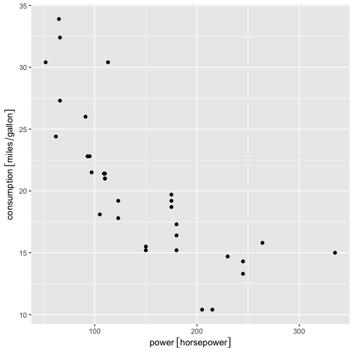

```r
miles <- as_units('miles')
gallon <- as_units('gallon')
horsepower <- as_units('horsepower')
mtcars$consumption <- mtcars$mpg * (miles/gallon)
mtcars$power <- mtcars$hp * horsepower

ggplot(mtcars) +
    geom_point(aes(power, consumption))
```

If data is transformed as part of an aesthetic assignment the unit will update automatically:

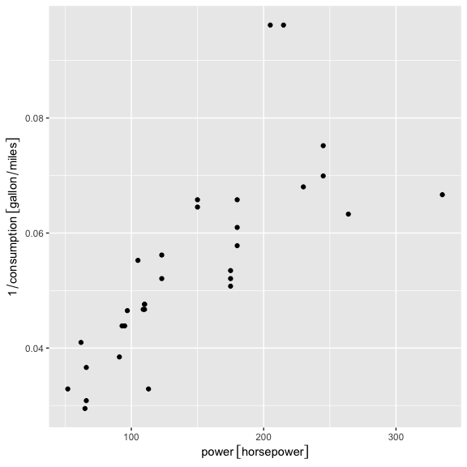

```r
ggplot(mtcars) +
    geom_point(aes(power, 1/consumption))
```

Lastly it is possible to change the units used for the axes on the fly without touching the underlying data through the `unit` argument in the scale constructor. When doing this the data is automatically converted to the new unit.

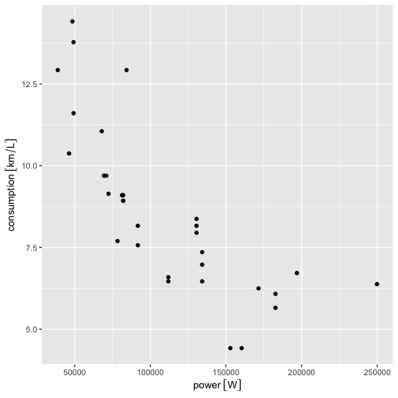

```r
ggplot(mtcars) +
    geom_point(aes(power, consumption)) +
    scale_x_unit(unit = 'W') +
    scale_y_unit(unit = 'km/l')
```

## Depth

See facet_stereo…

# A rocket

We’ll finish this of by drawing a rocket:

[figure not shown]

```r
rocketData <- data.frame(
  x = c(1,1,2,2),
  y = c(1,2,2,3)
)
rocketData <- do.call(rbind, lapply(seq_len(500)-1, function(i) {
  rocketData$y <- rocketData$y - c(0,i/500);
  rocketData$group <- i+1;
  rocketData
}))
rocketData2 <- data.frame(
  x = c(2, 2.25, 2),
  y = c(2, 2.5, 3)
)
rocketData2 <- do.call(rbind, lapply(seq_len(500)-1, function(i) {
  rocketData2$x[2] <- rocketData2$x[2] - i*0.25/500;
  rocketData2$group <- i+1 + 500;
  rocketData2
}))
ggplot() + geom_link(aes(x=2, y=2, xend=3, yend=3, alpha=..index..,
                     size = ..index..), colour='goldenrod', n=500) +
           geom_bezier(aes(x=x, y=y, group=group, colour=..index..),
                       data=rocketData) +
           geom_bezier(aes(x=y, y=x, group=group, colour=..index..),
                       data=rocketData) +
           geom_bezier(aes(x=x, y=y, group=group, colour=1),
                       data=rocketData2) +
           geom_bezier(aes(x=y, y=x, group=group, colour=1),
                       data=rocketData2) +
           geom_text(aes(x=1.65, y=1.65, label='ggplot2', angle=45),
                     colour='white', size=15) +
           coord_fixed() +
           scale_x_reverse() +
           scale_y_reverse() +
           scale_alpha(range=c(1, 0), guide='none') +
           scale_size_continuous(range=c(20, 0.1), trans='exp',
                                 guide='none') +
           scale_color_continuous(guide='none') +
           xlab('') + ylab('') +
           ggtitle('ggforce: Accelerating ggplot2') +
           theme(plot.title = element_text(size = 20))
```